# Lab 4: Advanced Data Wrangling

## Tidy Data

#### 1. Examine the built-in dataset `ChickWeight`. Which of the following is true:

- ChickWeight is not tidy: each chick has more than one row.
- **ChickWeight is tidy: each observation (a weight) is represented by one row. The chick from which this measurement came is one of the variables.**
- ChickWeight is not tidy: we are missing the year column.
- ChickWeight is tidy: it is stored in a data frame.

#### 2. Examine the built-in dataset BOD. Which of the following is true:

- BOD is not tidy: it only has six rows.
- BOD is not tidy: the first column is just an index.
- **BOD is tidy: each row is an observation with two values (time and demand)**
- BOD is tidy: all small datasets are tidy by definition.

## Reshaping Data and Joining Tables

#### 3. Run the following command to define the co2_wide object:

```r
library(tidyverse)
data(co2)
co2_wide <- data.frame(matrix(co2, ncol = 12, byrow = TRUE)) %>%
  setNames(1:12) %>%
  mutate(year = as.character(1959:1997))
```

Use the `pivot_long` function to wrangle this into a tidy dataset. Call the column with the CO2 measurements `co2` and call the month column `month`. Call the resulting object `co2_tidy`.

```r
co2_tidy <- co2_wide %>% pivot_longer(-year, names_to = "month", values_to = "co2")
```

#### 4. Plot CO2 versus month with a different curve for each year using this code:

```
## geom_path: Each group consists of only one observation. Do you need to adjust
## the group aesthetic?
```

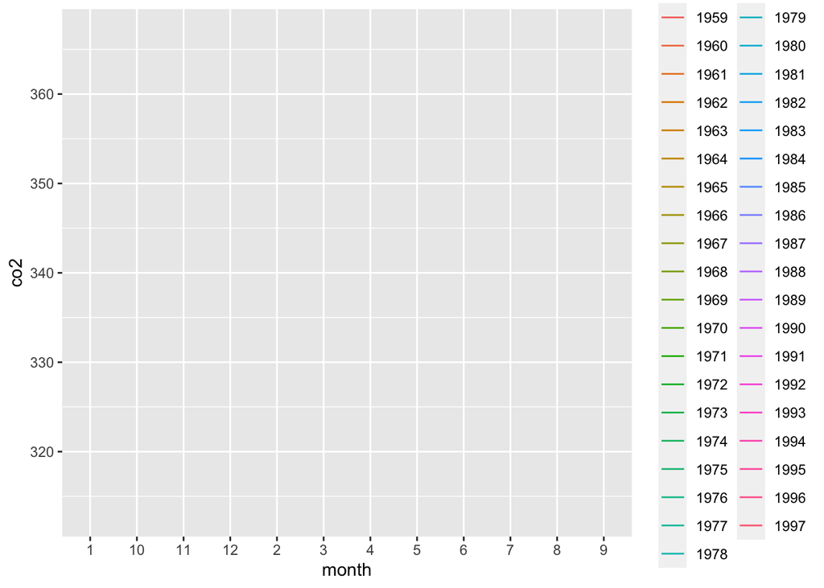

```r
co2_tidy %>% ggplot(aes(month, co2, color = year)) +
    geom_line()
```

If the expected plot is not made, it is probably because `co2_tidy$month` is not numeric:

```r
class(co2_tidy$month)
```

```
## [1] "character"
```

Rewrite your code to make sure the `month` column is numeric. Then remake the plot.

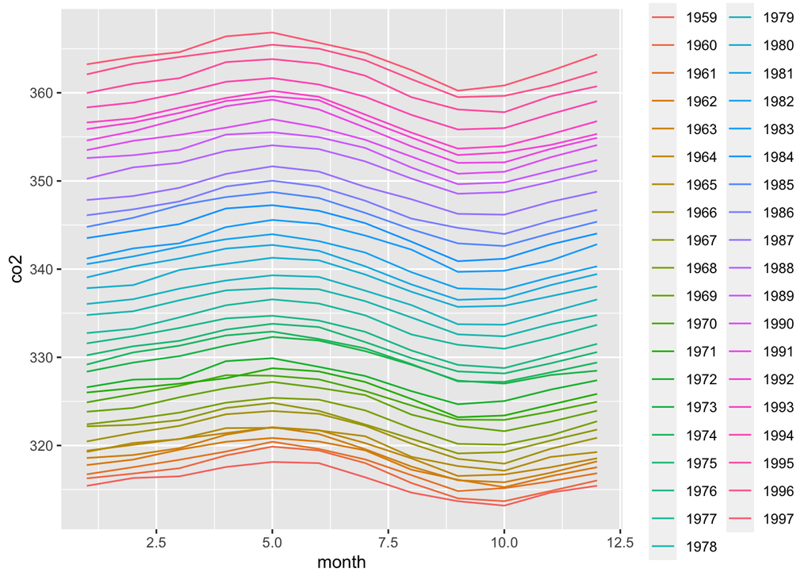

```r
co2_tidy <- co2_tidy %>% mutate(month = as.numeric(month))

co2_tidy %>% ggplot(aes(month, co2, color = year)) +
    geom_line()
```

#### 6. We want to see if the monthly trend is changing so we are going to remove the year effects and then plot the results. We will first compute the year averages. Use `group_by` and `summarize` to compute the average co2 for each year. Save in an object called `yearly_avg`.

```r
yearly_avg <- co2_tidy %>% group_by(year) %>%
    summarise(avg_co2 = mean(co2))

head(yearly_avg)
```

```
## # A tibble: 6 × 2
##   year  avg_co2
##   <chr>   <dbl>
## 1 1959     316.
## 2 1960     317.
## 3 1961     317.
## 4 1962     318.
## 5 1963     319.
## 6 1964     319.
```

#### 7. Now use the `left_join` function to add the yearly average to the `co2_tidy` dataset. Then compute the residuals: observed co2 measure - yearly average.

```r
combined_df <- co2_tidy %>% left_join(yearly_avg, by = "year") %>%
    mutate(residual = co2 - avg_co2)

head(combined_df)
```

```
## # A tibble: 6 × 5
##   year  month   co2 avg_co2 residual
##   <chr> <dbl> <dbl>   <dbl>    <dbl>
## 1 1959      1  315.    316.   -0.406
## 2 1959      2  316.    316.    0.484
## 3 1959      3  316.    316.    0.674
## 4 1959      4  318.    316.    1.73
## 5 1959      5  318.    316.    2.30
## 6 1959      6  318     316.    2.17
```

#### 8. Make a plot of the seasonal trends by year but only after removing the year effect.

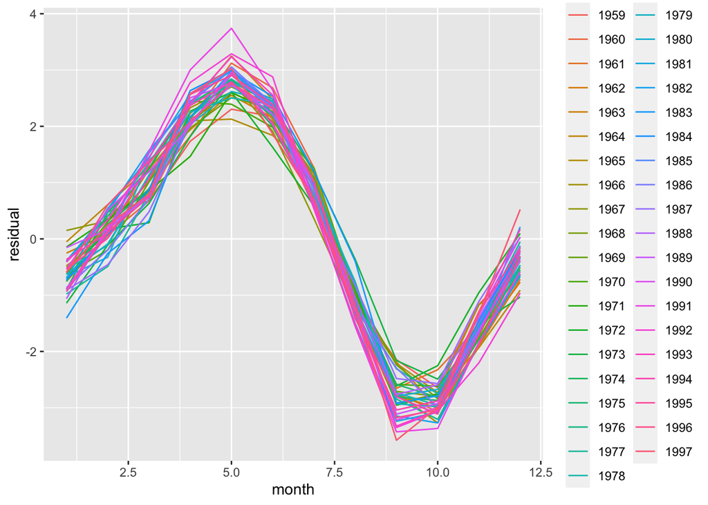

```r
combined_df %>% ggplot(aes(month, residual, color = year)) +
    geom_line()
```

#### 9. Install and load the `Lahman` library. This database includes data related to baseball teams. It includes summary statistics about how the players performed on offense and defense for several years. It also includes personal information about the players.

The `Batting` data frame contains the offensive statistics for all players for many years. You can see, for example, the top 10 hitters in 2016 by running this code:

```r
library(Lahman)
top <- Batting %>%
  filter(yearID == 2016) %>%
  arrange(desc(HR)) %>%
  slice(1:10)

head(top)
```

```
##    playerID yearID stint teamID lgID   G  AB   R   H X2B X3B HR RBI SB CS BB
## 1 trumbma01   2016     1    BAL   AL 159 613  94 157  27   1 47 108  2  0 51
## 2  cruzne02   2016     1    SEA   AL 155 589  96 169  27   1 43 105  2  0 62
## 3 daviskh01   2016     1    OAK   AL 150 555  85 137  24   2 42 102  1  2 42
## 4 doziebr01   2016     1    MIN   AL 155 615 104 165  35   5 42  99 18  2 61
## 5 encared01   2016     1    TOR   AL 160 601  99 158  34   0 42 127  2  0 87
## 6 arenano01   2016     1    COL   NL 160 618 116 182  35   6 41 133  2  3 68
##    SO IBB HBP SH SF GIDP
## 1 170   1   3  0  0   14
## 2 159   5   9  0  7   15
## 3 166   0   8  0  5   19
## 4 138   6   8  2  5   12
## 5 138   3   5  0  8   22
## 6 103  10   2  0  8   17
```

But who are these players? We see an ID, but not the names. The player names are in this table

```r
People %>% head()
```

```
##    playerID birthYear birthMonth birthDay birthCountry birthState  birthCity
## 1 aardsda01      1981         12       27          USA         CO     Denver
## 2 aaronha01      1934          2        5          USA         AL     Mobile
## 3 aaronto01      1939          8        5          USA         AL     Mobile
## 4  aasedo01      1954          9        8          USA         CA     Orange
## 5  abadan01      1972          8       25          USA         FL Palm Beach
## 6  abadfe01      1985         12       17         D.R.  La Romana  La Romana
##   deathYear deathMonth deathDay deathCountry deathState deathCity nameFirst
## 1        NA         NA       NA         <NA>       <NA>      <NA>     David
## 2      2021          1       22          USA         GA   Atlanta      Hank
## 3      1984          8       16          USA         GA   Atlanta    Tommie
## 4        NA         NA       NA         <NA>       <NA>      <NA>       Don
## 5        NA         NA       NA         <NA>       <NA>      <NA>      Andy
## 6        NA         NA       NA         <NA>       <NA>      <NA>  Fernando
##   nameLast        nameGiven weight height bats throws      debut  finalGame
## 1  Aardsma      David Allan    215     75    R      R 2004-04-06 2015-08-23
## 2    Aaron      Henry Louis    180     72    R      R 1954-04-13 1976-10-03
## 3    Aaron       Tommie Lee    190     75    R      R 1962-04-10 1971-09-26
## 4     Aase   Donald William    190     75    R      R 1977-07-26 1990-10-03
## 5     Abad    Fausto Andres    184     73    L      L 2001-09-10 2006-04-13
## 6     Abad Fernando Antonio    235     74    L      L 2010-07-28 2021-10-01
##    retroID   bbrefID  deathDate  birthDate
## 1 aardd001 aardsda01       <NA> 1981-12-27
## 2 aaroh101 aaronha01 2021-01-22 1934-02-05
## 3 aarot101 aaronto01 1984-08-16 1939-08-05
## 4 aased001  aasedo01       <NA> 1954-09-08
## 5 abada001  abadan01       <NA> 1972-08-25
## 6 abadf001  abadfe01       <NA> 1985-12-17
```

We can see column names `nameFirst` and `nameLast`. Use the `left_join` function to create a table of the top home run hitters. The table should have playerID, first name, last name, and number of home runs (HR). Rewrite the object `top` with this new table.

```r
top <- top %>% select(playerID, HR)
People <- People %>% select(playerID, nameFirst, nameLast)
top <- left_join(top, People, by = "playerID")
head(top)
```

```
##    playerID HR nameFirst    nameLast
## 1 trumbma01 47      Mark      Trumbo
## 2  cruzne02 43    Nelson        Cruz
## 3 daviskh01 42     Khris       Davis
## 4 doziebr01 42     Brian      Dozier
## 5 encared01 42     Edwin Encarnacion
## 6 arenano01 41     Nolan     Arenado
```

```r
top <- Salaries %>% filter(yearID == 2016) %>%
    select(playerID, salary) %>%
    right_join(top, by = "playerID")
```

[output not shown]

## Parsing Dates and Times

[output not shown]

Calling the `str()` function, we can see that the column for the date of the first case is a string, which means that R understands the contents as a set of characters and not as a date. So if we try to order our data frame by the date of the first case, R won’t do a good job.

```
## tibble [177 × 10] (S3: tbl_df/tbl/data.frame)
##  $ by_date     : int [1:177] 0 0 0 1 2 3 16 19 22 27 ...
##  $ by_continent: num [1:177] 0 0 0 1.01 1.02 1.03 1.04 1.05 1.06 1.07 ...
##  $ country     : chr [1:177] "World" "Days to double (approx)" "Countries and territories" "Mexico" ...
##  $ first_case  : chr [1:177] "2009-04-24" "" "" "2009-04-24" ...
##  $ April       : int [1:177] 25 NA 2 18 7 NA NA NA NA NA ...
##  $ May         : int [1:177] 367 2 13 156 141 34 NA NA NA NA ...
##  $ June        : int [1:177] 17398 15 63 5029 8975 1336 37 27 12 107 ...
##  $ July        : int [1:177] 77201 15 121 8680 27717 7983 279 226 254 417 ...
##  $ August      : int [1:177] 188333 28 168 16442 43771 10449 668 556 558 588 ...
##  $ latest      : int [1:177] 208269 29 175 17530 43771 10449 798 595 558 600 ...
```

But we can use the function `ymd()` to convert it into a date. Then we can use the converted date column to arrange our data frame according to the date of the first case.

```r
library(lubridate)
cases_df$first_case <- ymd(cases_df$first_case)
```

##### b) Calculate the time difference between each country’s first case and the previous country’s first case using the `lag()` function, and save it into a column called `first_case_diff`.

```r
cases_df$first_case_diff <- cases_df$first_case - lag(cases_df$first_case)
head(cases_df)
```

```
## # A tibble: 6 × 11
##   by_date by_continent country  first_case April   May  June  July August latest
##     <int>        <dbl> <chr>    <date>     <int> <int> <int> <int>  <int>  <int>
## 1       0         0    World    2009-04-24    25   367 17398 77201 188333 208269
## 2       0         0    Days to… NA            NA     2    15    15     28     29
## 3       0         0    Countri… NA             2    13    63   121    168    175
## 4       1         1.01 Mexico   2009-04-24    18   156  5029  8680  16442  17530
## 5       2         1.02 United … 2009-04-24     7   141  8975 27717  43771  43771
## 6       3         1.03 Canada   2009-04-27    NA    34  1336  7983  10449  10449
## # … with 1 more variable: first_case_diff <drtn>
## # ℹ Use `colnames()` to see all variable names
```